# Analysis of Car Sales By Different Manufacturers

**4. Sum of sales and basic statistics of the passenger and car vehicle types**

```python
car_sales.loc[car_sales['Vehicle_type'] == 'Passenger', 'Sales_in_thousands'].sum()
```

```
5015.184
```

```python
car_sales.loc[car_sales['Vehicle_type'] == 'Passenger', 'Sales_in_thousands'].mean()
```

```
43.234344827586206
```

```python
car_sales.loc[car_sales['Vehicle_type'] == 'Passenger', 'Sales_in_thousands'].median()
```

```
25.430500000000002
```

```python
car_sales.loc[car_sales['Vehicle_type'] == 'Passenger', 'Sales_in_thousands'].std()
```

```
50.55787508366736
```

```python
car_sales.loc[car_sales['Vehicle_type'] == 'Passenger', 'Sales_in_thousands'].max()
```

```
247.994
```

```python
car_sales.loc[car_sales['Vehicle_type'] == 'Passenger', 'Sales_in_thousands'].min()
```

```
0.11
```

*4.1. Density plot showing basic statistics of the sales of the passenger vehicle type*

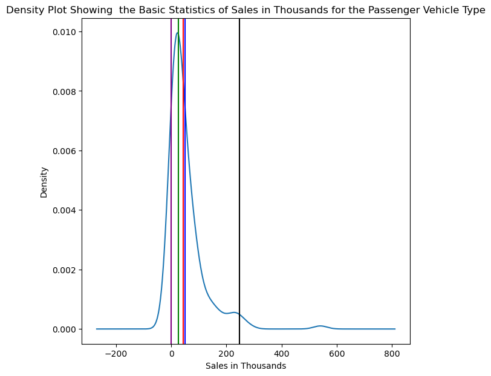

```python
df = car_sales['Sales_in_thousands'].plot(kind='density', figsize=(7,7))
df.axvline(car_sales.loc[car_sales['Vehicle_type'] == 'Passenger', 'Sales_in_thousands'].mean(), color = 'red')
df.axvline(car_sales.loc[car_sales['Vehicle_type'] == 'Passenger', 'Sales_in_thousands'].median(), color = 'green')
df.axvline(car_sales.loc[car_sales['Vehicle_type'] == 'Passenger', 'Sales_in_thousands'].max(), color = 'black')
df.axvline(car_sales.loc[car_sales['Vehicle_type'] == 'Passenger', 'Sales_in_thousands'].min(), color = 'purple')
df.axvline(car_sales.loc[car_sales['Vehicle_type'] == 'Passenger', 'Sales_in_thousands'].std(), color = 'blue')
plt.title("Density Plot Showing  the Basic Statistics of Sales in Thousands for the Passenger Vehicle Type")
plt.xlabel('Sales in Thousands')
plt.ylabel('Density')
```

```python
car_sales.loc[car_sales['Vehicle_type'] == 'Car', 'Sales_in_thousands'].sum()
```

```
3305.514
```

```python
car_sales.loc[car_sales['Vehicle_type'] == 'Car', 'Sales_in_thousands'].mean()
```

```
80.62229268292683
```

```python
car_sales.loc[car_sales['Vehicle_type'] == 'Car', 'Sales_in_thousands'].median()
```

```
51.238
```

```python
car_sales.loc[car_sales['Vehicle_type'] == 'Car', 'Sales_in_thousands'].max()
```

```
540.561
```

```python
car_sales.loc[car_sales['Vehicle_type'] == 'Car', 'Sales_in_thousands'].min()
```

```
9.126
```

```python
car_sales.loc[car_sales['Vehicle_type'] == 'Car', 'Sales_in_thousands'].std()
```

```
98.19262635560877
```

*4.2. Density plot showing basic statistics of the sales of car vehicle type*

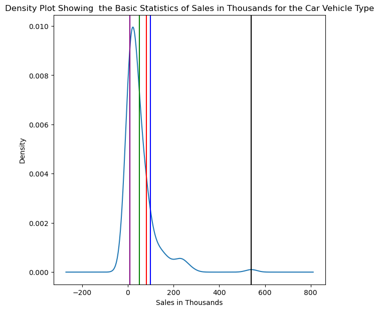

```python
df = car_sales['Sales_in_thousands'].plot(kind='density', figsize=(7,7))
df.axvline(car_sales.loc[car_sales['Vehicle_type'] == 'Car', 'Sales_in_thousands'].mean(), color = 'red')
df.axvline(car_sales.loc[car_sales['Vehicle_type'] == 'Car', 'Sales_in_thousands'].median(), color = 'green')
df.axvline(car_sales.loc[car_sales['Vehicle_type'] == 'Car', 'Sales_in_thousands'].max(), color = 'black')
df.axvline(car_sales.loc[car_sales['Vehicle_type'] == 'Car', 'Sales_in_thousands'].min(), color = 'purple')
df.axvline(car_sales.loc[car_sales['Vehicle_type'] == 'Car', 'Sales_in_thousands'].std(), color = 'blue')
plt.title("Density Plot Showing  the Basic Statistics of Sales in Thousands for the Car Vehicle Type")
plt.xlabel('Sales in Thousands')
plt.ylabel('Density')
```

*4.3. Boxplot comparing the passenger and car vehicle types in terms of their sales*

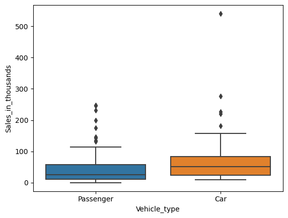

```python
sns.boxplot(data = car_sales, x = 'Vehicle_type', y = 'Sales_in_thousands')
```

- The sum of sales in thousands of the passenger vehicle type was 5015.184 and that of the car vehicle type 3305.514 repectively.
- The standard deviation shows that the sales in thousands of the car vehicle type is more dispersed around it's mean as compared to the dispersion of that of the passenger vehicle type.
- The car vehicle type also has higher minimum 9.126 thousands and maximum 540.561 thousands compared to that of the passenger vehicle type with minimum 0.11 thousands and maximum 247.994 thousands.
- The car sale vehicle type has fewer outliers than the passenger vehicle type.